# [이번 강의에서 다룰 그래프의 종류 (Matplotlib , Seaborn)]

- **1.선그래프 (plt.plot, sns.lineplot)**
- **2.막대그래프 (plt.bar, sns.barplot/sns.countplot)**
- **3.산점도 (plt.scatter, sns.scatterplot)**
- **4.히스토그램 (plt.hist, sns.histplot, displot)**
- **5.박스플롯 (plt.boxplot , sns.boxplot)**
- **6.히트맵 (sns.heatmap)**

# [ Matplotlib 라이브러리]

- 다양한 형태의 그래프 작성을 지원
- https://matplotlib.org/3.5.1/plot_types/index.html

```python
import numpy as np
import pandas as pd
import matplotlib.pyplot as plt

import warnings as wn
wn.filterwarnings('ignore')
```

```python
# [참고] 아래 두 표현은 동일함
import matplotlib.pyplot as plt     # 1
```

```python
from matplotlib import pyplot as plt   # 2
```

## 1.plt.plot(x,y) 그래프의 시작 - 선 그래프

- plot함수 (선 그래프)
- 함수의 parameter 설정을 변경 가능 (기본적으로, x, y에 해당하는 값이 필요)
- plt의 다른 함수로 그래프 형태 변경 가능
- bar(막대 그래프), scatter(점 그래프), hist(히스토그램) 등 사용

```python
x= [1, 2, 3, 4, 5, 6, 7, 8, 9, 10]
y= [100, 200, 300, 400, 500, 600, 700, 800, 900, 1000]
```

```python
plt.plot(x, y)
plt.show()  #마지막에 선언해주면 속성 관련 출력 메시지 등이 생략되어 그래프만 깔끔하게 출력
```

### 1) 그래프에 주석 추가

- **x, y 축 레이블 및 타이틀**

```python
plt.xlabel('study time')
plt.ylabel('score')
plt.title('X-Y relation')

plt.plot(x, y)
plt.show()
```

- **grid 추가**

```python
plt.xlabel('study time')
plt.ylabel('score')
plt.title('X-Y relation')
plt.grid(True)

plt.plot(x, y)
plt.show()
```

- **x, y축 범위 지정**
- 방법1 - plt.xlim ([xmin, xmax]), plt.ylim ([ymin, ymax])

```python
plt.xlabel('study time')
plt.ylabel('score')
plt.title('X-Y relation')

plt.xlim(0, 20)
plt.ylim(0, 1500)
plt.plot(x, y)

plt.show()
```

### 2) plot 함수 parameters

- 다양한 파라미터를 이용하여 그래프의 형태에 대한 제어 가능
- plt.plot (x값, y값, 색상/형태 등을 위한 파라미터)
- 그래프의 색상 변경

```python
plt.plot(x, y, color='r')
```

- **그래프 컬러의 간단옵션**

```python
plt.plot(x, y, color='g')
```

- **그래프 선스타일 변경**
- plt.plot(x, y, linestyle='dashed') = plt.plot(x, y, linestyle='--')
- plt.plot(x, y, linestyle='solid') = plt.plot(x, y, linestyle='-')
- plt.plot(x, y, linestyle='dotted') = plt.plot(x, y, linestyle=':')
- plt.plot(x, y, linestyle='dashdot') = plt.plot(x, y, linestyle='-.')

```python
plt.plot(x, y, linestyle='dashed')
```

- 색깔과 형태 동시 지정

```python
plt.plot(x, y, 'g:')
```

```python
plt.plot(x, y, 'r-')
```

```python
plt.plot(x, y, 'b--')
```

- **그래프 두께 변경 - linewidth**

```python
plt.plot(x, y, 'b--', linewidth=5)
```

## 2. Bar - 막대 그래프

- **단순히 x에 해당되는 y값을 bar차트로 그리는 것**
- **seaborn의 barplot과 비교필요!**
- 월별(x) 판매량(y) 데이터

```python
x= [1, 2, 3, 4, 5, 6, 7, 8, 9, 10, 11, 12]
```

```python
y= [300, 400, 550, 900, 600, 960, 900, 910, 800, 700, 550, 450]
```

```python
plt.bar(x,y)
```

```python
plt.bar(x,y, color='r')
```

- **stacked bar plot**

```python
men = [20, 35, 30, 35, 27]
women = [25, 32, 34, 20, 25]
```

- 5개의 그룹을 설정하여 x location으로 세팅
- numpy.arange([start, ] stop, [step, ]) : Return evenly spaced values within a given interval

```python
group = list(range(1,6))
```

```python
group
```

- bottom=men 을 이용하여 stacked bar 구성

```python
plt.bar(group, men, color='red')
plt.bar(group, women, color='blue', bottom=men)
```

### bar에 숫자를 넣고 싶을 때

```python
x = [1,2,3,4,5]
y = [20, 35, 30, 35, 27]
plt.bar(x,y)

for i in (1,2,3,4,5):
    plt.text(i, 10, y[i-1])                 # x좌표, y좌표, 표시할 값(y)
plt.show()

# 만약 막대의 끝에 표시되도록 하려면 어떻게 바꾸면 될까?    10--> y[i-1]
```

## 3. 산점도 그래프(scatter)

- 변수간 상관관계 확인에 용이

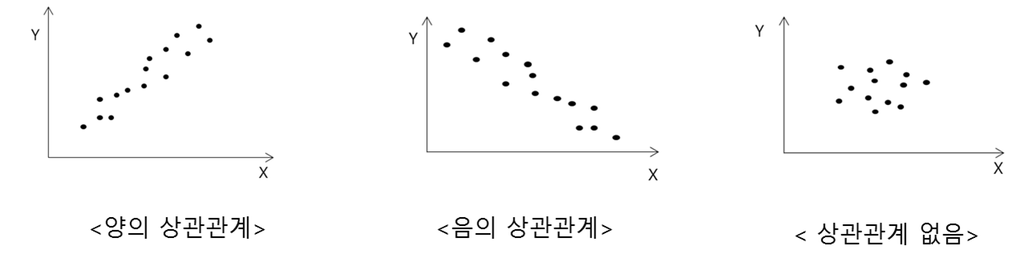

```python
import seaborn as sns   #데이터 로드를 위해 사용
```

```python
tips = sns.load_dataset("tips")
```

```python
tips.head()
```

```python
x = tips['total_bill']
```

```python
y = tips['tip']
```

```python
(x, y)
```

```python
plt.scatter(x,y)
```

- **어떤 가설이 가능할까?**

## 4. 히스토그램

- random.randint(low, high, size) : Return random integers from low (inclusive) to high (exclusive)
- data = np.random.randint(1, 100, size=200): 1에서 99까지 정수 200개

```python
data = np.random.randint(low=1, high=100, size=200)
#data = np.random.randint(1,100, 200)
```

```python
data
```

- bins=가로축 구간수
- bins 지정하지 않으면 디폴트는 10개

```python
plt.hist(data, bins=20)
plt.grid(True)
plt.show()
```

### 누적 히스토그램

- cumulative=True

```python
plt.hist(data, bins=20,  cumulative=True)
plt.grid(True)
plt.show()
```

## 5. 박스플롯

- outlier가 있는 데이터를 로드하기 위해 seaborn의 tips 데이터 셋 이용

```python
import seaborn as sns
```

```python
tips = sns.load_dataset("tips")
```

```python
x = tips['day']
```

```python
plt.boxplot(x)  # matplotlib.pyplot.boxplot(x, ...)
plt.show()
```

### 관련용어

- 백분위 수 : 데이터를 백등분 한 것
- 사분위 수 : 데이터를 사등분 한 것
- 제 1사분위 수 (Q1) : 전체 데이터 중 하위 25%에 해당하는 값
- 제 2사분위 수 (Q2) : 전체 데이터 중 하위(상위) 50%에 해당하는 값 = 중간값 (median)
- 제 3사분위 수 (Q3) : 전체 데이터 중 하위 75% (상위 25%)에 해당하는 값
- 제 4사분위 수 (Q4) : 전체 데이터 중 하위 100% (가장 상위)에 해당하는 값
- IQR (사분위 범위) : Q3 - Q1 (데이터의 중간 50%)

### 그리는 방법

- 1.전체 데이터에서 각 사분위수를 계산한다.(Q1,Q2,Q3,Q4)
- 2.그래프에서 제1 사분위와 제3 사분위를 밑변으로 하는 직사각형을 그리고, 제 2사분위에 해당하는 위치(중앙값)에 선분을 긋는다.
- 3.사분위수 범위(IQR = Q3-Q1)을 계산한다.
- 4.Q3+1.5IQR보다 크거나, Q1-1.5IQR의 위치에 max와 min을 표시하고 그보다 바깥쪽의 데이터는 이상치로 간주한다.

# [Seaborn 라이브러리]

- Matplotlib 기반위에 구현
- 다양한 통계 그래프 작성에 용이
- https://seaborn.pydata.org/examples/index.html

```python
import numpy as np
import pandas as pd
import matplotlib.pyplot as plt
import seaborn as sns
```

## 1. sns.lineplot

```python
x= [1, 2, 3, 4, 5, 6, 7, 8, 9, 10]
y= [100, 200, 300, 400, 500, 600, 700, 800, 900, 1000]
```

```python
sns.lineplot(x,y)
```

- **만약 data가 DataFrame라면?**
- 5월 탑승객수만 뽑아서 그림

```python
# 데이터 로드
flights = sns.load_dataset("flights")
```

```python
flights.head()
```

```python
may_flights = flights.query("month == 'May'")
```

```python
may_flights
```

```python
sns.lineplot(x="year", y="passengers",data=may_flights)
```

```python
sns.barplot(x="year", y="passengers",data=may_flights)
```

## 2.1 Barplot

- **특정변수의 평균값을 bar plotting**
- **ex) 요일별 tip값의 평균을 보고 싶다면?**
- **(Counterplot과 비교!)**
- tips 데이터 로딩

```python
tips = sns.load_dataset("tips")
```

```python
tips.head(30)
```

- **sns.barplot(xdata, ydata, DataFrame)**

```python
sns.barplot(x='day', y='tip',data=tips)
plt.show()
```

- **각 막대에 기본적으로 오차막대(error bar)가 함께 나타남**
- **오차막대: 신뢰구간(confidence interval)**
- **이 데이터를 기반으로 유사한 상황의 95 % 범위 내에서 결과를 얻을 것을 의미**
- **ci=sd(표준편차로 그림),ci=None(오차막대 안그림)**

```python
sns.barplot(x='day', y='tip', data=tips, ci='sd')
plt.show()
```

```python
sns.barplot(x='day', y='tip', data=tips, ci=None)
plt.show()
```

- 구분자 hue

```python
sns.barplot(x="day", y="tip", hue="sex", data=tips, ci=None)
plt.show()
```

## 2.2 countplot

- **데이터의 갯수를 count하여 barplotting**

```python
sns.countplot(x = "day", data = tips)
plt.show()
```

- **남녀 구분을 하고싶다면**

```python
sns.countplot(x = "day", data = tips, hue = "sex")
plt.show()
```

## 3. scatterplot - 산점도와 회귀선이 있는 산점도

### 1) 산점도

- tips 데이터 로딩

```python
sns.scatterplot(x = "total_bill", y = "tip", data = tips)
```

### 2) 회귀선이 있는 산점도

```python
sns.regplot(x = "total_bill", y = "tip", data = tips)
```

- fit_reg = False: 회귀선이 나오지 않도록 설정

```python
sns.regplot(x = "total_bill", y = "tip", data = tips, fit_reg = False)
```

## 4. 히스토그램/커널 밀도 그래프 - histplot, displot

### 1) 히스토그램

```python
#! pip install seaborn
#! pip install matplotlib

#seaborn버전이 낮을 경우 histplot, displot이 되지 않음. 업그레이드 필요함
#업그레이드 후에는 커널을 다시 시작해야 함
```

```python
#  tips 데이터
tips
```

```python
sns.histplot(x = "tip", data = tips)
plt.show()
```

```python
#  kind="hist" 옵션일 때 histplot과 동일
sns.displot(data = tips, x = "tip", kind="hist")  # kind{“hist”, “kde”, “ecdf”}
plt.show()

# kde-kernel density estimation
# ecdf-empirical cumulative distribution functions
```

```python
sns.displot(data = tips, x = "tip", kind="kde")  # kind{“hist”, “kde”, “ecdf”}
plt.show()
```

```python
sns.displot(data = tips, x = "tip", kind="ecdf")  # kind{“hist”, “kde”, “ecdf”}
plt.show()
```

## 5.박스플롯

```python
sns.boxplot(x = "day", y = "total_bill", data = tips)
plt.show()

# seaborn.boxplot(data=None, x=None, y=None,... )
```

## 6. Heatmap

### 1) 상관관계 그래프

```python
import pandas as pd
import numpy as np
import seaborn as sns
import matplotlib.pyplot as plt
```

```python
mpg = sns.load_dataset("mpg")
```

```python
mpg.shape
```

- mpg: 자동차 연비와 관련된 데이터 세트
- 변수: 9개, 데이터: 398 세트

```python
mpg.head()
```

```python
# 문자형 데이터인 origin과 name 열을 삭제해 보자!
mpg.drop(['origin','name'],axis=1, inplace=True)
```

```python
mpg.head()   #origin, name이 빠진것을 알 수 있음!
```

- corr() : 변수간 상관계수 표현
- 수치형 데이터만 사용

```python
mpg.corr()
```

```python
corr=mpg.corr()
```

### 2) seaborn의 heatmap() 함수

- sns.heatmap ( , annot=True, ) --> 상관관계 수치 표시

```python
sns.heatmap(corr, annot=True, cmap="BrBG")     # annot=True --> 상관관계 수치 표시
```

### 3) heatmap에서 대각선을 중심으로 대칭이므로 하단만 나오게 만들어 보자!

- **heatmap()의 mask 파라미터 이용!**
- np.ones_like() : Return an array of ones with the same shape and type as a given array
- np.triu() : Return a copy of an array with the elements below the k-th diagonal zeroed

```python
np.ones_like(num_mpg_corr)    #전부 1로 변경
```

```python
np.triu(np.ones_like(num_mpg_corr))   #upper triangle만 남기고 대각선 아래는 전부 0으로 변경
```

```python
mask_check = np.triu(np.ones_like(num_mpg.corr()))
```

```python
mask_check
```

- Correlation Heatmap에 'mask=mask' 파라미터 추가! --> True값에 해당하는 셀만 사라짐(mask)

```python
sns.heatmap(num_mpg_corr, annot=True, cmap="BrBG",mask=mask_check)
```

- 변수간 상관관계를 직관적으로 이해할 수 있음 ### Target 변수인 mpg를 대상으로 볼때
- Clylinders, displacement, horsepower, weight 는 강한 음의 상관관계를 가진다!